# Food Deserts Analysis

### Train/Test Split

We split the data into train and test. Test set has 20% of data. This is to check overfitting and check the performance for unseen data.

```r
print(nrow(cleaned_data))
```

```
## [1] 67543
```

```r
n <- nrow(cleaned_data)
# Calculate the size of the training set (e.g., 80% of the dataset)
trainSize <- floor(0.8 * n)
# Randomly sample row indices for the training set
trainIndex <- sample(seq_len(n), size = trainSize)
# Create training and test datasets
trainData <- cleaned_data[trainIndex, ]
testData <- cleaned_data[-trainIndex, ]
```

```r
select_cart_vars = c("MedianFamilyIncome","LowIncomeTracts","TractSNAP","TractHUNV","TractSeniors","TractWhite","TractBlack")

formula_str_pov_linr <- paste("PovertyRate ~", paste(select_cart_vars, collapse = " + "))
formula_obj_pov_linr <- as.formula(formula_str_pov_linr)
pov_linr_model = lm(formula_obj_pov_linr , data=trainData)
sum_pov_linr_model = summary(pov_linr_model)  # this is easier to be used in the inline codes to pull out coefficients and other info
sum_pov_linr_model
```

```
##
## Call:
## lm(formula = formula_obj_pov_linr, data = trainData)
##
## Residuals:
##    Min     1Q Median     3Q    Max
## -38.80  -3.74  -0.46   3.11  76.87
##
## Coefficients:
##                     Estimate Std. Error t value Pr(>|t|)
## (Intercept)         1.71e+01   1.34e-01  127.55  < 2e-16 ***
## MedianFamilyIncome -7.58e-05   1.30e-06  -58.12  < 2e-16 ***
## LowIncomeTracts1    9.87e+00   9.28e-02  106.33  < 2e-16 ***
## TractSNAP           1.82e-02   2.83e-04   64.46  < 2e-16 ***
## TractHUNV           4.19e-03   1.61e-04   26.09  < 2e-16 ***
## TractSeniors       -4.13e-03   1.18e-04  -34.99  < 2e-16 ***
## TractWhite         -5.76e-04   2.61e-05  -22.04  < 2e-16 ***
## TractBlack         -2.08e-04   4.62e-05   -4.49  7.1e-06 ***
## ---
## Signif. codes:  0 '***' 0.001 '**' 0.01 '*' 0.05 '.' 0.1 ' ' 1
##
## Residual standard error: 7.62 on 54026 degrees of freedom
## Multiple R-squared:  0.633,  Adjusted R-squared:  0.633
## F-statistic: 1.33e+04 on 7 and 54026 DF,  p-value: <2e-16
```

```r
#xkabledply(sum_pov_linr_model)
```

### Performance of the Linear Regression for Povery Rate

```r
testData$pred = predict(pov_linr_model,testData)
trainData$pred = predict(pov_linr_model,trainData)
#print(testData$pred)
print("Test Data R2")
```

```
## [1] "Test Data R2"
```

```r
test_lin_R2 = adjustedR2(testData,length(select_cart_vars),pov_linr_model)
print(test_lin_R2)
```

```
## [1] 0.63287
```

```r
print("Train Data R2")
```

```
## [1] "Train Data R2"
```

```r
train_lin_R2 = adjustedR2(trainData,length(select_cart_vars),pov_linr_model)
print(train_lin_R2)
```

```
## [1] 0.63263
```

```r
print(pov_linr_model)
```

```
##
## Call:
## lm(formula = formula_obj_pov_linr, data = trainData)
##
## Coefficients:
##        (Intercept)  MedianFamilyIncome    LowIncomeTracts1           TractSNAP
##           1.71e+01           -7.58e-05            9.87e+00            1.82e-02
##          TractHUNV        TractSeniors          TractWhite          TractBlack
##           4.19e-03           -4.13e-03           -5.76e-04           -2.08e-04
```

```r
sum = summary(pov_linr_model)
#capture.output(sum, file = "chiffon_drafts/models/lm_pov_summary.txt")
residuals <- testData$PovertyRate -testData$pred
# Calculate RMSE
rmse <- sqrt(mean(residuals^2))
# Print the RMSE
print("The RMSE")
```

```
## [1] "The RMSE"
```

```r
print(rmse)
```

```
## [1] 7.6486
```

```r
metrics_data_povertyrate <- rbind(metrics_data_povertyrate, c("Linear", "R2", test_lin_R2))
metrics_data_povertyrate <- rbind(metrics_data_povertyrate, c("Linear", "RMSE", rmse))
```

- The adjusted R square of the Linear Regression model for test set is 0.63287. The train set R2 is 0.63263. Indicates that there is no overfitting and the model is decent in explaining the poverty rate.
- The RMSE of the linear model for poverty rate is 7.64855.

## Comparison of CART and Linear Regression Metrics.

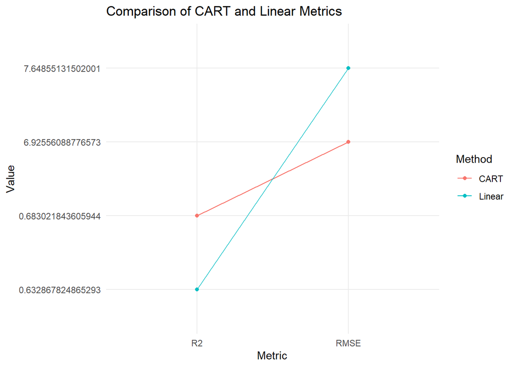

```r
# Create the line graph using ggplot2
ggplot(metrics_data_povertyrate, aes(x = Metric, y = Value, group = Method, color = Method)) +
  geom_line() +
  geom_point() +
  labs(title = "Comparison of CART and Linear Metrics",
       x = "Metric",
       y = "Value") +
  theme_minimal()
```

## Best models

- From the model comparison we found that CART performs better for povery rate prediction compared to linear regression.
- Our smart question are more prediction related and our final R2 score for best cart model for the povery rate is 0.68302. Our predictions are very good and it is validated from the good R2 score for test set

#Conclusion: The analysis revealed significant connections between factors such as vehicle availability, income, ethnicity, and the prevalence of food deserts. Additionally, examining poverty rates further informed our recommendations. Among these suggestions are:

**Targeted Support for Specific Ethnicities and Communities:** Recognizing the pivotal role of median family income, it’s essential to launch initiatives aimed at specific ethnic groups and communities. These should focus on enhancing financial literacy and stability.

**Community-Oriented Educational Programs:** We advocate for the implementation of educational initiatives that foster knowledge about nutrition, cooking, and healthy eating practices within the community. This might encompass cooking workshops, nutrition classes, and programs integrated into school curricula.

**Enhancing Public Transport Systems:** By improving public transportation networks, we can ensure easier access to grocery stores for individuals who do not own vehicles.

**Broadening the Scope of Online Grocery Services:** We recommend expanding the availability of online grocery shopping and delivery options in areas identified as food deserts, which would be particularly beneficial for residents facing mobility challenges or without access to personal transport.

According to another article, “Food Research & Action Center Calls for WIC Funding, SNAP Benefit Adequacy as Rates of Hunger Rise” (FFAC Staff, 2023), from Food Research & Action Center (FRAC), stated today by the U.S. Department of Agriculture’s Economic Research Service (ERS), that the COVID-19 pandemic relief efforts caused hunger in America to decline the previous year, but it surged in 2022. So additional information on how covid affected food desert status would be beneficial